# Practical Machine Learning Coursera Project

Mekin Lertanuntasuk

4/14/2018

## Overview

The goal of this analysis is to build machine learning models to predict the manner in which people exercise using the data from accelerometers on the belt, forearm, arm, and dumbell of 6 participants. In this report, we are going to describe how we built the models, how we used cross validation, and what is the expected out of sample error.

The data for this project come from this source: http://groupware.les.inf.puc-rio.br/har.

## Summary

Of all the three machine learning models we tried, random forest turned out to be the best with out-of-sample accuracy of 99.8%. Using generalized boosted regression, we can also acheive about 99% accuracy on the test set. Nevertheless, the descision tree turned out to be the worst with less than 50% accuracy.

## Environment setup

First, let’s load the required libraries for the analysis

```r
set.seed(1234)
library(caret)
```

Let’s load the training and validation dataset

```r
training = read.csv(url("https://d396qusza40orc.cloudfront.net/predmachlearn/pml-training.csv"), header=T)
validation = read.csv(url("https://d396qusza40orc.cloudfront.net/predmachlearn/pml-testing.csv"), header=T)
```

## Data cleaning and preprocessing

Let’s look at how our dataset looks like

```r
dim(training)
```

```
## [1] 19622   160
```

```r
str(training)
```

```
## 'data.frame':    19622 obs. of  160 variables:
##  $ X                       : int  1 2 3 4 5 6 7 8 9 10 ...
##  $ user_name               : Factor w/ 6 levels "adelmo","carlitos",..: 2 2 2 2 2 2 2 2 2 2 ...
##  $ raw_timestamp_part_1    : int  1323084231 1323084231 1323084231 1323084232 1323084232 1323084232 1323084232 1323084232 1323084232 1323084232 ...
##  $ raw_timestamp_part_2    : int  788290 808298 820366 120339 196328 304277 368296 440390 484323 484434 ...
##  $ cvtd_timestamp          : Factor w/ 20 levels "02/12/2011 13:32",..: 9 9 9 9 9 9 9 9 9 9 ...
##  $ new_window              : Factor w/ 2 levels "no","yes": 1 1 1 1 1 1 1 1 1 1 ...
##  $ num_window              : int  11 11 11 12 12 12 12 12 12 12 ...
##  $ roll_belt               : num  1.41 1.41 1.42 1.48 1.48 1.45 1.42 1.42 1.43 1.45 ...
##  $ pitch_belt              : num  8.07 8.07 8.07 8.05 8.07 8.06 8.09 8.13 8.16 8.17 ...
##  $ yaw_belt                : num  -94.4 -94.4 -94.4 -94.4 -94.4 -94.4 -94.4 -94.4 -94.4 -94.4 ...
##  $ total_accel_belt        : int  3 3 3 3 3 3 3 3 3 3 ...
##  $ kurtosis_roll_belt      : Factor w/ 397 levels "","-0.016850",..: 1 1 1 1 1 1 1 1 1 1 ...
##  $ kurtosis_picth_belt     : Factor w/ 317 levels "","-0.021887",..: 1 1 1 1 1 1 1 1 1 1 ...
##  $ kurtosis_yaw_belt       : Factor w/ 2 levels "","#DIV/0!": 1 1 1 1 1 1 1 1 1 1 ...
```

[output cut: 86 more lines]

We can see that there are about 20K records with 160 columns. We can also see that for some columns, there are a lot of NA or blank values. Let’s see what those columns are.

```r
countNA = sapply(training, function(y) sum(length(which(is.na(y)|y==""))))
countNA[countNA>0]
```

```
##       kurtosis_roll_belt      kurtosis_picth_belt        kurtosis_yaw_belt
##                    19216                    19216                    19216
##       skewness_roll_belt     skewness_roll_belt.1        skewness_yaw_belt
##                    19216                    19216                    19216
##            max_roll_belt           max_picth_belt             max_yaw_belt
##                    19216                    19216                    19216
##            min_roll_belt           min_pitch_belt             min_yaw_belt
##                    19216                    19216                    19216
##      amplitude_roll_belt     amplitude_pitch_belt       amplitude_yaw_belt
##                    19216                    19216                    19216
##     var_total_accel_belt            avg_roll_belt         stddev_roll_belt
##                    19216                    19216                    19216
##            var_roll_belt           avg_pitch_belt        stddev_pitch_belt
##                    19216                    19216                    19216
##           var_pitch_belt             avg_yaw_belt          stddev_yaw_belt
##                    19216                    19216                    19216
##             var_yaw_belt            var_accel_arm             avg_roll_arm
##                    19216                    19216                    19216
##          stddev_roll_arm             var_roll_arm            avg_pitch_arm
##                    19216                    19216                    19216
##         stddev_pitch_arm            var_pitch_arm              avg_yaw_arm
##                    19216                    19216                    19216
##           stddev_yaw_arm              var_yaw_arm        kurtosis_roll_arm
##                    19216                    19216                    19216
##       kurtosis_picth_arm         kurtosis_yaw_arm        skewness_roll_arm
##                    19216                    19216                    19216
##       skewness_pitch_arm         skewness_yaw_arm             max_roll_arm
##                    19216                    19216                    19216
##            max_picth_arm              max_yaw_arm             min_roll_arm
##                    19216                    19216                    19216
##            min_pitch_arm              min_yaw_arm       amplitude_roll_arm
##                    19216                    19216                    19216
##      amplitude_pitch_arm        amplitude_yaw_arm   kurtosis_roll_dumbbell
##                    19216                    19216                    19216
##  kurtosis_picth_dumbbell    kurtosis_yaw_dumbbell   skewness_roll_dumbbell
##                    19216                    19216                    19216
##  skewness_pitch_dumbbell    skewness_yaw_dumbbell        max_roll_dumbbell
##                    19216                    19216                    19216
##       max_picth_dumbbell         max_yaw_dumbbell        min_roll_dumbbell
##                    19216                    19216                    19216
```

[output cut: 13 more lines]

```
##                    19216                    19216                    19216
##         max_roll_forearm        max_picth_forearm          max_yaw_forearm
##                    19216                    19216                    19216
##         min_roll_forearm        min_pitch_forearm          min_yaw_forearm
##                    19216                    19216                    19216
##   amplitude_roll_forearm  amplitude_pitch_forearm    amplitude_yaw_forearm
##                    19216                    19216                    19216
##        var_accel_forearm         avg_roll_forearm      stddev_roll_forearm
##                    19216                    19216                    19216
##         var_roll_forearm        avg_pitch_forearm     stddev_pitch_forearm
##                    19216                    19216                    19216
##        var_pitch_forearm          avg_yaw_forearm       stddev_yaw_forearm
##                    19216                    19216                    19216
##          var_yaw_forearm
##                    19216
```

We can see that there are 100 columns with mostly NA or blank values. We are going to remove them as they don’t provide us any information. Also, we are going to further remove the first five columns as they are just containing the data about the users who did the exercise and the timestamp.

```r
training = training[, names(countNA[countNA==0])]
training = training[, -c(1:5)]
```

```r
dim(training)
```

```
## [1] 19622    55
```

We can see that our data now has only 55 columns.

Now let’s split the training data into 70% training and 30% testing for further model building and evaluation.

```r
inTrain = createDataPartition(y=training$classe, p=0.7, list=FALSE)
training_data = training[inTrain,]
testing_data = training[-inTrain,]
```

In order to avoid the problem with overfitting, we are going to use 5-fold cross validation technique (obviously, 10 might be better, but we want to save computational time).

```r
control = trainControl(method = "cv", number = 5)
```

## Models building

We are going to try 3 different models here and compare the accuracy between each model. The models that we are going to try are:

- decision trees
- Generalized Boosted Regression Models
- random forests

First, let’s start with the decision trees

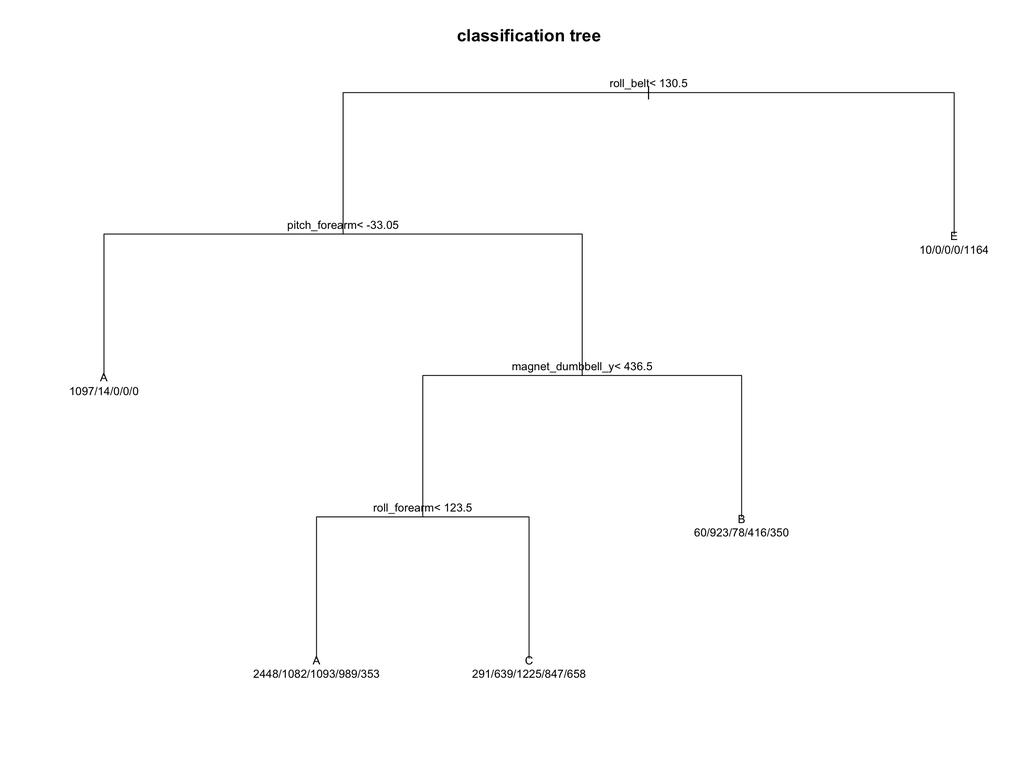

```r
treeFit = train(classe~., method ="rpart", data=training_data, trControl = control)
plot(treeFit$finalModel, uniform=TRUE, main = "classification tree")
text(treeFit$finalModel, use.n=TRUE, cex = .8)
```

```r
treePred = predict(treeFit, newdata = testing_data)
treeResult = confusionMatrix(treePred, testing_data$classe)
treeResult$overall["Accuracy"]
```

```
##  Accuracy
## 0.4890399
```

```r
treeResult$table
```

```
##           Reference
## Prediction    A    B    C    D    E
##          A 1530  486  493  452  168
##          B   35  379   31  164  145
##          C  105  274  502  348  302
##          D    0    0    0    0    0
##          E    4    0    0    0  467
```

We can see that the accuracy for this model is pretty bad, even lower than 50% on the test set. Looking at the confusion matrix, we are doing pretty good at predicting class E. But, we didn’t predict anything to be class D.

Let’s see how well we could do using generalized boosting method.

```r
gbmFit = train(classe~., method ="gbm", data=training_data, verbose=FALSE, trControl = control)
gbmPred = predict(gbmFit, newdata = testing_data)
gbmResult = confusionMatrix(gbmPred, testing_data$classe)
gbmResult$overall["Accuracy"]
```

```
##  Accuracy
## 0.9862362
```

```r
gbmResult$table
```

```
##           Reference
## Prediction    A    B    C    D    E
##          A 1673   16    0    0    1
##          B    0 1107    7    5    3
##          C    0   13 1016   12    4
##          D    1    3    2  945   11
##          E    0    0    1    2 1063
```

Comparing to the accuracy of the model generated by decision trees, Generalized Boosted Regression Model is much better. It could achieve about 99% accuracy on the test set.

Let’s try out the random forest model for fun.

```r
rfFit = train(classe~., method ="rf", data=training_data, trControl = control)
rfPred = predict(rfFit, newdata = testing_data)
rfResult = confusionMatrix(rfPred, testing_data$classe)
rfResult$overall["Accuracy"]
```

```
##  Accuracy
## 0.9979609
```

```r
rfResult$table
```

```
##           Reference
## Prediction    A    B    C    D    E
##          A 1674    3    0    0    0
##          B    0 1135    4    0    0
##          C    0    1 1022    1    0
##          D    0    0    0  963    3
##          E    0    0    0    0 1079
```

It looks like that we can still improve the accuracy of the model a bit by using random forest. The accuracy on the test set is about 99.8% which is very high. Therefore, we can expect a very small out-of-sample error (less than ~ 1%).

## Prediction on the validation set

Based on the project’s requirement, we will predict the class for the 20 observations in the validation dataset. We will base our result from the random forest model since it has the highest accuracy. Additional, we will also use the genalarized boosting model to check whether we got different outcomes or not.

```r
rf = predict(rfFit, newdata = validation)
gbm = predict(gbmFit, newdata = validation)
```

```r
data.frame(rf,gbm)
```

```
##    rf gbm
## 1   B   B
## 2   A   A
## 3   B   B
## 4   A   A
## 5   A   A
## 6   E   E
## 7   D   D
## 8   B   B
## 9   A   A
## 10  A   A
## 11  B   B
## 12  C   C
## 13  B   B
## 14  A   A
## 15  E   E
## 16  E   E
## 17  A   A
## 18  B   B
## 19  B   B
## 20  B   B
```

We can see that both models yield the same results on the validation set.